# The Initial Database

# LUXEMBOURG

```python
#Luxembourg: import/export analysis

lux_imp_users_table = imp_users_table_getter("Luxembourg")
lux_exp_users_table = exp_users_table_getter("Luxembourg")
lux_imp_cont_table = imp_cont_table_getter("Luxembourg")
lux_exp_cont_table = exp_cont_table_getter("Luxembourg")

#Luxembourg imports by sector
lux_imp_users_table = lux_imp_users_table.drop(1,2).with_columns("Commercial", make_array(4,7,1,1,18,1))
lux_imp_users_table
```

| Country of Contractor | Government/Military | Commercial |
| --- | --- | --- |
| France | 0 | 4 |
| France/United Kingdom/Germany | 0 | 7 |
| France/United Kingdom/Germany/Spain | 0 | 1 |
| Germany/France | 0 | 1 |
| USA | 1 | 18 |
| United Kingdom | 0 | 1 |

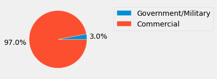

```python
#Luxembourg imports by sector
pie_chart(lux_imp_users_table, 2.7,1)
```

```python
#Luxembourg imports by contractor
lux_imp_cont_table
```

| Country of Contractor | Airbus Defense and Space | Astrium | Boeing Satellite Systems | EADS Astrium | Hughes Space and Communications Co. | Lockheed Martin Commercial Space Systems | Orbital ATK | Orbital Sciences Corp. | Space Systems/Loral | Thales Alenia Space |
| --- | --- | --- | --- | --- | --- | --- | --- | --- | --- | --- |
| France | 0 | 0 | 0 | 4 | 0 | 0 | 0 | 0 | 0 | 0 |
| France/United Kingdom/Germany | 4 | 1 | 0 | 2 | 0 | 0 | 0 | 0 | 0 | 0 |
| France/United Kingdom/Germany/Spain | 0 | 0 | 0 | 1 | 0 | 0 | 0 | 0 | 0 | 0 |
| Germany/France | 1 | 0 | 0 | 0 | 0 | 0 | 0 | 0 | 0 | 0 |
| USA | 0 | 0 | 5 | 0 | 5 | 2 | 1 | 4 | 2 | 0 |
| United Kingdom | 0 | 0 | 0 | 0 | 0 | 0 | 0 | 0 | 0 | 1 |

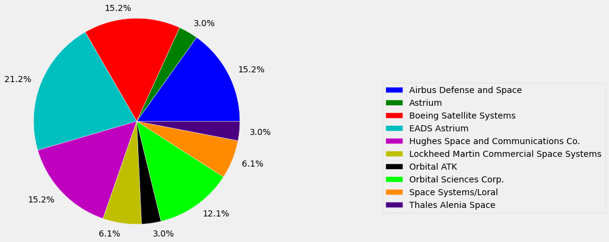

```python
#Luxembourg imports by contractor
pie_chart(lux_imp_cont_table, 6,1)
```

```python
#Luxembourg exports by sector
lux_exp_users_table
```

| Country of Contractor | Government |
| --- | --- |
| Luxembourg | 1 |

```python
#Luxembourg exports by contractor
lux_exp_cont_table
```

| Country of Contractor | LuxSpace |
| --- | --- |
| Luxembourg | 1 |

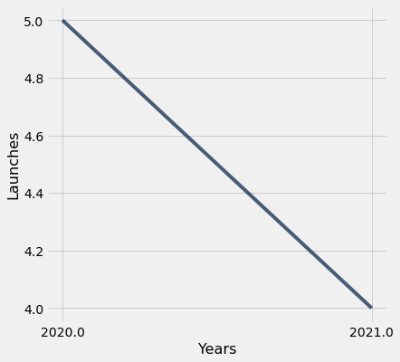

```python
#Luxembourg: Launches vs. Time for Space Objects produced in Luxembourg. Can denote domestic-use or exported products.
launch_plot_nonzero("Luxembourg")
```

| Country of Operator/Owner | Communications | Earth Observation |
| --- | --- | --- |
| Luxembourg | 33 | 8 |

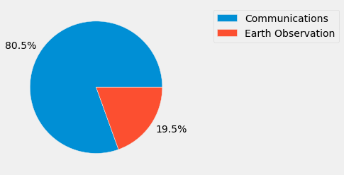

```python
#Luxembourg (sovereign authority) satellite usage breakdown
lux = purp_table_getter("Luxembourg")
lux.show()
pie_lux = lux.drop("Country of Operator/Owner")
plots.pie(x=pie_lux.row(0),labels=labels_2(lux))
plots.legend(labels=pie_lux.labels,loc='upper right', bbox_to_anchor=(2,1))
```

# NETHERLANDS

```python
#Netherlands: import/export analysis

neth_imp_users_table = imp_users_table_getter("Netherlands")
neth_exp_users_table = exp_users_table_getter("Netherlands")
neth_imp_cont_table = imp_cont_table_getter("Netherlands")
neth_exp_cont_table = exp_cont_table_getter("Netherlands")

#Netherlands imports by sector
neth_imp_users_table
```

| Country of Contractor | Civil | Commercial |
| --- | --- | --- |
| France | 0 | 1 |
| USA | 0 | 6 |
| United Kingdom/Netherlands | 1 | 0 |

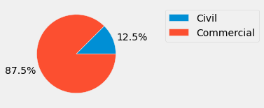

```python
#Netherlands: Imports By Sector
pie_chart(neth_imp_users_table, 2.4,1)
```

```python
#Netherlands imports by contractor
neth_imp_cont_table
```

| Country of Contractor | AMSAT/UK-AMSAT/NL | Alcatel Space Industries | Lockheed Martin Commercial Space Systems | Orbital Sciences Corp. | Space Systems/Loral |
| --- | --- | --- | --- | --- | --- |
| France | 0 | 1 | 0 | 0 | 0 |
| USA | 0 | 0 | 4 | 1 | 1 |
| United Kingdom/Netherlands | 1 | 0 | 0 | 0 | 0 |

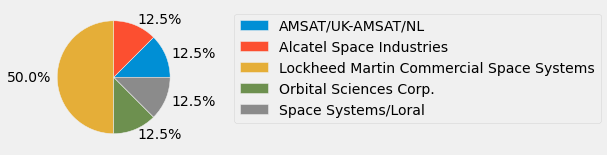

```python
#Netherlands: Imports By Contractor
pie_chart(neth_imp_cont_table, 4,1)
```

```python
#Netherlands exports by sector
neth_exp_users_table
```

| Country of Contractor | Commercial | Military |
| --- | --- | --- |
| Netherlands | 2 | 2 |

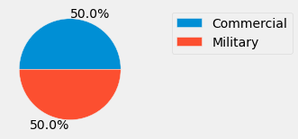

```python
#Netherlands: Exports By Sector
pie_chart(neth_exp_users_table, 2.3,1)
```

```python
#Netherlands exports by contractor
neth_exp_cont_table
```

| Country of Contractor | Innovative Solutions in Space | Innovative Solutions in Space BV |
| --- | --- | --- |
| Netherlands | 2 | 2 |

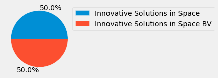

```python
#Netherlands: Exports By Contractor
pie_chart(neth_exp_cont_table, 3,1)
```

# NORWAY

```python
#Norway: import/export analysis

nor_imp_users_table = imp_users_table_getter("Norway")
nor_exp_users_table = exp_users_table_getter("Norway")
nor_imp_cont_table = imp_cont_table_getter("Norway")
nor_exp_cont_table = exp_cont_table_getter("Norway")

#Norway has no recorded exports
```

[output not shown]

## Norway imports by sector

```python
nor_imp_users_table
```

| Country of Contractor | Commercial | Government |
| --- | --- | --- |
| Canada | 0 | 1 |
| France/Italy | 1 | 0 |
| Norway/Canada | 0 | 1 |
| USA | 2 | 0 |

## Norway: Imports By Sector

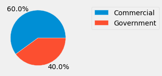

```python
pie_chart(nor_imp_users_table,2.3,1)
```

## Norway imports by contractor

```python
#Norway imports by contractor
nor_imp_cont_table
```

| Country of Contractor | Kongsberg Seatex AS/University of Toronto Institute for Aerospace Studies | Orbital Sciences Corp. | Space Systems/Loral | Thales Alenia Space |
| --- | --- | --- | --- | --- |
| Canada | 1 | 0 | 0 | 0 |
| France/Italy | 0 | 0 | 0 | 1 |
| Norway/Canada | 1 | 0 | 0 | 0 |
| USA | 0 | 1 | 1 | 0 |

## Norway: Imports By Contractor

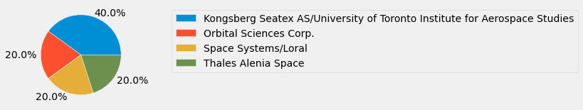

```python
pie_chart(nor_imp_cont_table, 5.5,1)
```

## Norway: Launches vs. Time for Space Objects produced in Norway. Can denote domestic-use or exported products.

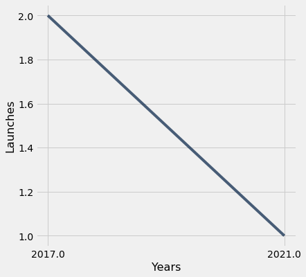

```python
launch_plot_nonzero("Norway")
```

## Norway (sovereign authority) satellite usage breakdown

| Country of Operator/Owner | Communications | Earth Observation | Earth Science/Earth Observation |
| --- | --- | --- | --- |
| Norway | 5 | 2 | 1 |

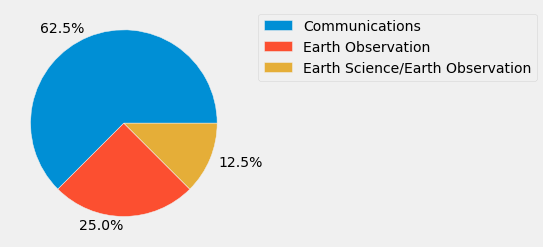

```python
nor = purp_table_getter("Norway")
nor.show()
pie_nor = nor.drop("Country of Operator/Owner")
plots.pie(x=pie_nor.row(0),labels=labels_2(nor))
plots.legend(labels=pie_nor.labels,loc='upper right', bbox_to_anchor=(2.3,1))
```

## Norway's Sovereign Capabilities by Contractor

```python
Nor_cap_piv = Sat_Table.where("Country of Operator/Owner", are.containing("Norway")).pivot("Contractor", "Purpose").show()
```

| Purpose | Kongsberg Seatex AS/University of Toronto Institute for Aerospace Studies | Norwegian Space Center | Orbital Sciences Corp. | Space Systems/Loral | Thales Alenia Space |
| --- | --- | --- | --- | --- | --- |
| Communications | 2 | 0 | 1 | 1 | 1 |
| Earth Observation | 0 | 2 | 0 | 0 | 0 |
| Earth Science/Earth Observation | 0 | 1 | 0 | 0 | 0 |

## NEW ZEALAND has no recorded imports/exports

# POLAND

```python
#Poland import/export analysis

pol_exp_users_table = exp_users_table_getter("Poland")
pol_exp_cont_table = exp_cont_table_getter("Poland")

#Poland had no recorded imports

#Poland exports by sector
pol_exp_users_table
```

| Country of Contractor | Government |
| --- | --- |
| Poland | 1 |

```python
#Poland exports by contractor
pol_exp_cont_table
```

| Country of Contractor | Space Research Center, Polish Academy of Sciences |
| --- | --- |
| Poland | 1 |

## ROMANIA has no recorded imports/exports

# SOUTH KOREA

```python
#South Korea: import/export analysis

skor_imp_users_table = imp_users_table_getter("South Korea").take(make_array(0,1,3,4)).drop("Civil")
skor_exp_users_table = exp_users_table_getter("South Korea")
skor_imp_cont_table = imp_cont_table_getter("South Korea").take(make_array(0,1,3,4)).drop(2)
skor_exp_cont_table = exp_cont_table_getter("South Korea")

#South Korea imports by sector
skor_imp_users_table
```

| Country of Contractor | Commercial | Government/Commercial | Military | Military/Commercial |
| --- | --- | --- | --- | --- |
| France/Italy | 2 | 0 | 0 | 1 |
| France/United Kingdom/Germany/Spain | 0 | 0 | 1 | 0 |
| South Korea/France/United Kingdom/Germany | 0 | 2 | 0 | 0 |
| USA | 1 | 0 | 0 | 0 |

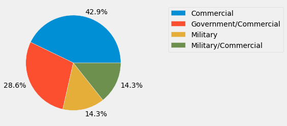

```python
#South Korea: Imports By Sector
pie_chart(skor_imp_users_table, 2.3,1)
```

```python
#South Korea imports by contractor
skor_imp_cont_table
```

| Country of Contractor | Airbus Defense and Space | Korea Aerospace Research Institute (KARI)/ EADS Astrium | Orbital Sciences Corp. | Thales Alenia Space |
| --- | --- | --- | --- | --- |
| France/Italy | 0 | 0 | 0 | 3 |
| France/United Kingdom/Germany/Spain | 1 | 0 | 0 | 0 |
| South Korea/France/United Kingdom/Germany | 0 | 2 | 0 | 0 |
| USA | 0 | 0 | 1 | 0 |

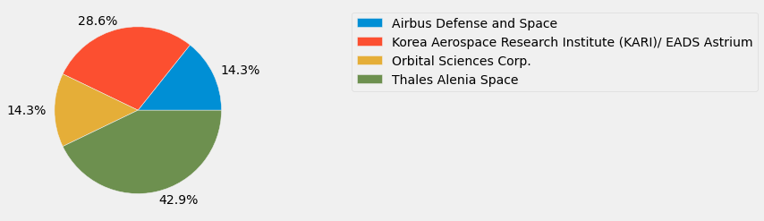

```python
#South Korea: Imports By Contractor
pie_chart(skor_imp_cont_table, 3.5,1)
```

```python
#South Korea exports by sector
skor_exp_users_table
```

| Country of Contractor | Government |
| --- | --- |
| South Korea | 2 |

```python
#South Korea exportsby contractor
skor_exp_cont_table
```

| Country of Contractor | Satrec Initiative |
| --- | --- |
| South Korea | 2 |

# SPAIN

```python
#Spain: import/export analysis

esp_imp_users_table = imp_users_table_getter("Spain")
esp_exp_users_table = exp_users_table_getter("Spain")
esp_imp_cont_table = imp_cont_table_getter("Spain")
esp_exp_cont_table = exp_cont_table_getter("Spain")

#Spain has no recorded exports

#Spain imports by sector
esp_imp_users_table
```

| Country of Contractor | Commercial | Government | Government/Commercial/Military | Military | Military/Commercial | Military/Government |
| --- | --- | --- | --- | --- | --- | --- |
| Denmark | 2 | 0 | 0 | 0 | 0 | 0 |
| France | 0 | 0 | 1 | 0 | 0 | 0 |
| France/United Kingdom/Germany/Spain | 1 | 0 | 0 | 0 | 0 | 0 |
| France/United Kingdom/Spain | 0 | 0 | 0 | 0 | 1 | 0 |
| Germany | 1 | 0 | 0 | 0 | 0 | 0 |
| South Korea | 0 | 1 | 0 | 0 | 0 | 0 |
| USA | 5 | 0 | 0 | 1 | 0 | 1 |
| United Kingdom | 1 | 1 | 0 | 0 | 0 | 0 |

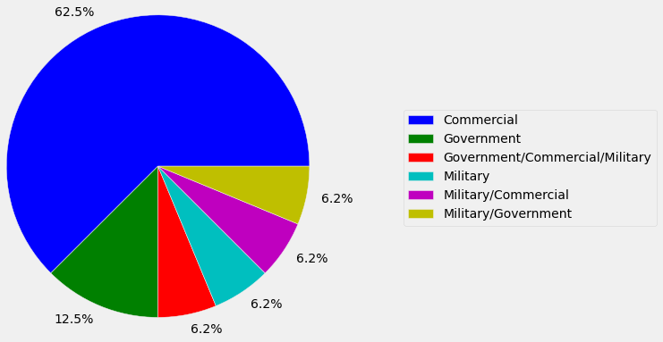

```python
#Spain: Imports By Sector
pie_chart(esp_imp_users_table, 4.5,1)
```

```python
#Spain imports by contractor
esp_imp_cont_table
```

| Country of Contractor | Airbus Defense and Space | Alcatel Space Industries | EADS Astrium | GomSpace ApS | OHB System-AG | Open Cosmos | Orbital Sciences Corp. | Satrec Initiative | Space Systems/Loral | Surrey Satellite Technology Ltd. |
| --- | --- | --- | --- | --- | --- | --- | --- | --- | --- | --- |
| Denmark | 0 | 0 | 0 | 2 | 0 | 0 | 0 | 0 | 0 | 0 |
| France | 0 | 1 | 0 | 0 | 0 | 0 | 0 | 0 | 0 | 0 |
| France/United Kingdom/Germany/Spain | 0 | 0 | 1 | 0 | 0 | 0 | 0 | 0 | 0 | 0 |
| France/United Kingdom/Spain | 1 | 0 | 0 | 0 | 0 | 0 | 0 | 0 | 0 | 0 |
| Germany | 0 | 0 | 0 | 0 | 1 | 0 | 0 | 0 | 0 | 0 |
| South Korea | 0 | 0 | 0 | 0 | 0 | 0 | 0 | 1 | 0 | 0 |
| USA | 0 | 0 | 0 | 0 | 0 | 0 | 1 | 0 | 6 | 0 |
| United Kingdom | 0 | 0 | 0 | 0 | 0 | 1 | 0 | 0 | 0 | 1 |

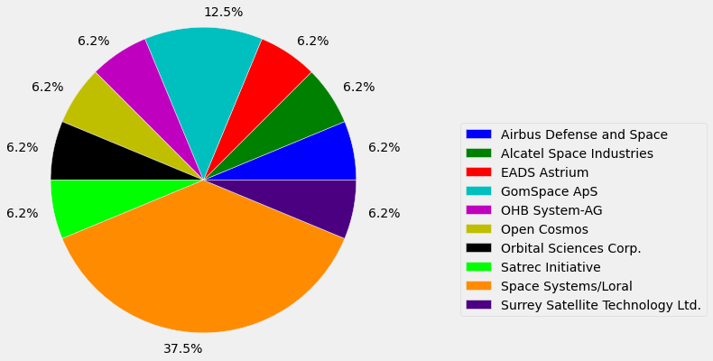

```python
#Spain: Imports By Contractor
pie_chart(esp_imp_cont_table, 4.5,1)
```

# THAILAND

```python
#Thailand: import/export analysis

thai_imp_users_table = imp_users_table_getter("Thailand")
thai_exp_users_table = exp_users_table_getter("Thailand")
thai_imp_cont_table = imp_cont_table_getter("Thailand")
thai_exp_cont_table = exp_cont_table_getter("Thailand")

#Thailand has no recorded exports

#Thailand imports by sector
thai_imp_users_table
```

| Country of Contractor | Civil | Commercial | Government | Military |
| --- | --- | --- | --- | --- |
| France | 0 | 0 | 1 | 0 |
| Germany | 1 | 0 | 0 | 0 |
| Netherlands | 0 | 0 | 0 | 2 |
| USA | 0 | 3 | 0 | 0 |

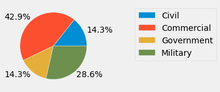

```python
#Thailand: Imports By Sector
pie_chart(thai_imp_users_table, 2.5,1)
```

```python
#Thailand imports by contractor
thai_imp_cont_table
```

| Country of Contractor | EADS Astrium | German Orbital Systems | Innovative Solutions in Space | Orbital ATK | Orbital Sciences Corp. | Space Systems/Loral |
| --- | --- | --- | --- | --- | --- | --- |
| France | 1 | 0 | 0 | 0 | 0 | 0 |
| Germany | 0 | 1 | 0 | 0 | 0 | 0 |
| Netherlands | 0 | 0 | 2 | 0 | 0 | 0 |
| USA | 0 | 0 | 0 | 1 | 1 | 1 |

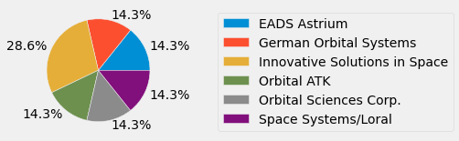

```python
#Thailand: Imports By Contractor
pie_chart(thai_imp_cont_table, 3.3,1)
```

# UNITED KINGDOM

```python
#United Kingdom: import/export analysis

uk_imp_users_table = imp_users_table_getter("United Kingdom")
uk_exp_users_table = exp_users_table_getter("United Kingdom")
uk_imp_cont_table = imp_cont_table_getter("United Kingdom")
uk_exp_cont_table = exp_cont_table_getter("United Kingdom")
```

[output not shown]

## United Kingdom imports by sector

```python
uk_imp_users_table
```

| Country of Contractor | Commercial | Military |
| --- | --- | --- |
| Denmark | 4 | 0 |
| France | 22 | 0 |
| France/United Kingdom/Germany | 3 | 4 |
| France/United Kingdom/Germany/Spain | 1 | 0 |
| USA | 292 | 0 |

## United Kingdom: Imports By Sector

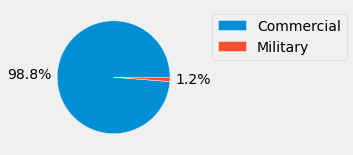

```python
pie_chart(uk_imp_users_table, 2.2, 1)
```

## United Kingdom imports by contractor

```python
uk_imp_cont_table
```

| Country of Contractor | Airbus Defence and Space | Astrium | Boeing Corp. | EADS Astrium | GOMSpace | GomSpace ApS | Lockheed Martin Commercial Space Systems | OneWeb Satellites/Airbus | Orbital Sciences Corp. | Thales Alenia Space |
| --- | --- | --- | --- | --- | --- | --- | --- | --- | --- | --- |
| Denmark | 0 | 0 | 0 | 0 | 1 | 3 | 0 | 0 | 0 | 0 |
| France | 0 | 0 | 0 | 1 | 0 | 0 | 0 | 0 | 0 | 21 |
| France/United Kingdom/Germany | 0 | 2 | 0 | 5 | 0 | 0 | 0 | 0 | 0 | 0 |
| France/United Kingdom/Germany/Spain | 1 | 0 | 0 | 0 | 0 | 0 | 0 | 0 | 0 | 0 |
| USA | 0 | 0 | 4 | 0 | 0 | 0 | 2 | 284 | 2 | 0 |

## United Kingdom: Imports By Contractor

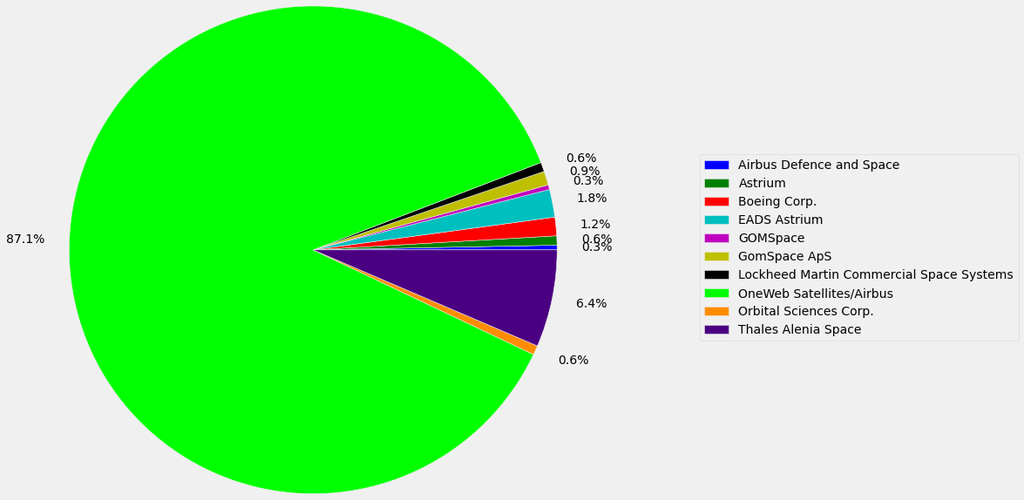

```python
pie_chart(uk_imp_cont_table, 4, 1)
```

## United Kingdom exports by sector

```python
uk_exp_users_table
```

| Country of Contractor | Commercial | Government | Military |
| --- | --- | --- | --- |
| United Kingdom | 11 | 13 | 4 |

## United Kingdom: Exports By Sector

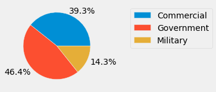

```python
pie_chart(uk_exp_users_table, 2.4,1)
```

## United Kingdom exports by contractor

```python
uk_exp_cont_table
```

| Country of Contractor | Clyde Space | Maxar | Open Cosmos | Surrey Satellite Technology Ltd. | Surrey Satellite Technology Ltd. | Thales Alenia Space |
| --- | --- | --- | --- | --- | --- | --- |
| United Kingdom | 2 | 3 | 2 | 15 | 1 | 5 |

## United Kingdom: Exports By Contractor

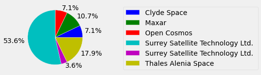

```python
pie_chart(uk_exp_cont_table, 3.5,1)
```

## United Kingdom: Launches vs. Time for Space Objects produced in United Kingdom. Can denote domestic-use or exported products.

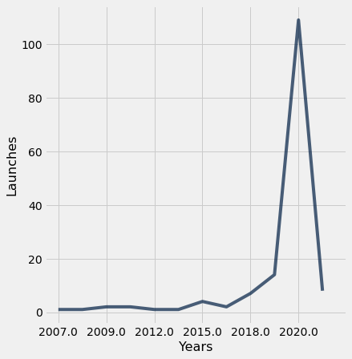

```python
launch_plot_nonzero("United Kingdom")
united_k = plots.xticks(range(0,14,2))
```

## United Kingdom (sovereign authority) satellite usage breakdown

| Country of Operator/Owner | Communications | Earth Observation | Platform | Space Science | Technology Development |
| --- | --- | --- | --- | --- | --- |
| United Kingdom | 436 | 6 | 1 | 1 | 6 |

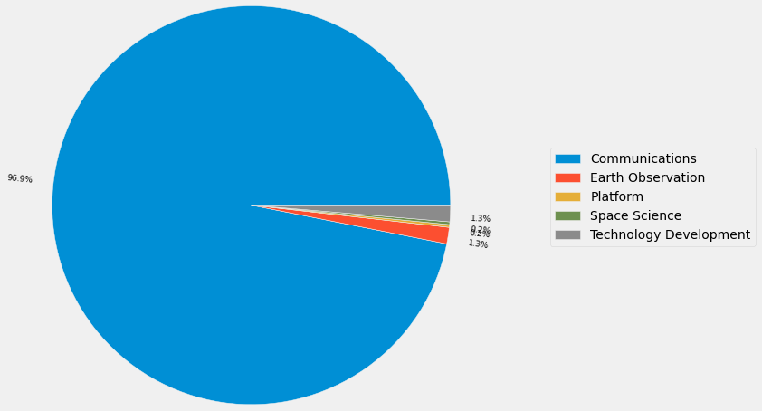

```python
uk = purp_table_getter("United Kingdom")
uk.show()
pie_uk = uk.drop("Country of Operator/Owner")
plots.pie(x=pie_uk.row(0),labels=labels_2(uk),radius =3.9, textprops={'fontsize': 9}, rotatelabels = True)
plots.legend(labels=pie_uk.labels,loc='upper right', bbox_to_anchor=(4.5,1))
```

## United Kingdom's Sovereign Capabilities by Contractor

```python
UK_cap_piv = Sat_Table.where("Country of Operator/Owner", are.containing("United Kingdom")).pivot("Contractor", "Purpose").show()
```

| Purpose | Airbus Defence and Space | Astrium | Boeing Corp. | Clyde Space | EADS Astrium | GOMSpace | GomSpace ApS | Lockheed Martin Commercial Space Systems | OneWeb Satellites/Airbus | Open Cosmos | Orbital Sciences Corp. | Spectrum Astro (General Dynamics) | Surrey Satellite Technologies Ltd./Airbus Defense and Space | Surrey Satellite Technology Ltd. | Surrey Satellite Technology Ltd. | Thales Alenia Space | University of Manchester |
| --- | --- | --- | --- | --- | --- | --- | --- | --- | --- | --- | --- | --- | --- | --- | --- | --- | --- |
| Communications | 1 | 2 | 4 | 1 | 8 | 0 | 0 | 2 | 394 | 2 | 2 | 0 | 0 | 0 | 0 | 22 | 0 |
| Communications/Technology Development | 0 | 1 | 0 | 0 | 0 | 0 | 0 | 0 | 0 | 0 | 0 | 0 | 0 | 0 | 0 | 0 | 0 |
| Earth Observation | 0 | 0 | 0 | 0 | 0 | 0 | 0 | 0 | 0 | 0 | 0 | 0 | 1 | 4 | 1 | 0 | 0 |
| Platform | 0 | 0 | 0 | 0 | 0 | 1 | 0 | 0 | 0 | 0 | 0 | 0 | 0 | 0 | 0 | 0 | 0 |
| Space Science | 0 | 0 | 0 | 0 | 0 | 0 | 0 | 0 | 0 | 0 | 0 | 1 | 0 | 0 | 0 | 0 | 1 |
| Technology Development | 0 | 0 | 0 | 0 | 0 | 0 | 3 | 0 | 0 | 0 | 0 | 0 | 0 | 3 | 0 | 0 | 0 |

## United Kingdom's SPECIFIC Sovereign Capabilities by Contractor

```python
UK_spec_cap_piv = Sat_Table.where("Country of Operator/Owner", are.containing("United Kingdom")).pivot("Contractor", "Detailed Purpose").show()
```

| Detailed Purpose | Airbus Defence and Space | Astrium | Boeing Corp. | Clyde Space | EADS Astrium | GOMSpace | GomSpace ApS | Lockheed Martin Commercial Space Systems | OneWeb Satellites/Airbus | Open Cosmos | Orbital Sciences Corp. | Spectrum Astro (General Dynamics) | Surrey Satellite Technologies Ltd./Airbus Defense and Space | Surrey Satellite Technology Ltd. | Surrey Satellite Technology Ltd. | Thales Alenia Space | University of Manchester |
| --- | --- | --- | --- | --- | --- | --- | --- | --- | --- | --- | --- | --- | --- | --- | --- | --- | --- |
| Internet of Things (IoT) | 0 | 0 | 0 | 1 | 0 | 0 | 0 | 0 | 0 | 2 | 0 | 0 | 0 | 0 | 0 | 0 | 0 |
| Optical Imaging | 0 | 0 | 0 | 0 | 0 | 0 | 0 | 0 | 0 | 0 | 0 | 0 | 0 | 4 | 1 | 0 | 0 |
| Radar Imaging | 0 | 0 | 0 | 0 | 0 | 0 | 0 | 0 | 0 | 0 | 0 | 0 | 1 | 0 | 0 | 0 | 0 |
| nan | 1 | 3 | 4 | 0 | 8 | 1 | 3 | 2 | 394 | 0 | 2 | 1 | 0 | 3 | 0 | 22 | 1 |

# USA

```python
#USA: import/export analysis

us_imp_users_table = imp_users_table_getter("USA")
us_exp_users_table = exp_users_table_getter("USA")
us_imp_cont_table = imp_cont_table_getter("USA")
us_exp_cont_table = exp_cont_table_getter("USA")

#USA imports by sector
us_imp_users_table
```

| Country of Contractor | Civil | Commercial | Government | Government/Civil | Government/Commercial |
| --- | --- | --- | --- | --- | --- |
| Denmark/Canada | 0 | 3 | 0 | 0 | 0 |
| France | 0 | 3 | 0 | 0 | 0 |
| France/Italy | 0 | 1 | 0 | 0 | 0 |
| France/Italy/USA | 0 | 0 | 0 | 0 | 75 |
| Germany/France | 0 | 1 | 0 | 0 | 0 |
| Italy | 0 | 24 | 0 | 0 | 0 |
| USA/Italy | 0 | 7 | 0 | 0 | 0 |
| USA/Thales Alenia Space | 0 | 7 | 0 | 0 | 0 |
| USA/United Kingdom | 1 | 0 | 0 | 0 | 0 |
| United Kingdom | 0 | 4 | 1 | 0 | 0 |

... (2 rows omitted)

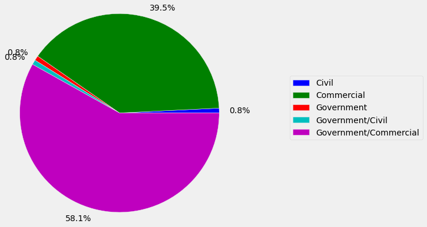

```python
#USA: Imports By Sector
pie_chart(us_imp_users_table, 4.2,1)
```

```python
#USA imports by contractor
us_imp_cont_table.show()
```

| Country of Contractor | Airbus Defense and Space | Alcatel Space Industries | EADS Astrium | GomSpace/Unitas SFL | LeoStella | Maxar | Space Systems/Loral/Alenia Aerospazio | Surrey Satellite Technology Ltd. | Thales Alenia Space | Thales Alenia Space/Orbital ATK | University of Colorado, Boulder | University of North Carolina/Clyde |
| --- | --- | --- | --- | --- | --- | --- | --- | --- | --- | --- | --- | --- |
| Denmark/Canada | 0 | 0 | 0 | 3 | 0 | 0 | 0 | 0 | 0 | 0 | 0 | 0 |
| France | 1 | 2 | 0 | 0 | 0 | 0 | 0 | 0 | 0 | 0 | 0 | 0 |
| France/Italy | 0 | 0 | 0 | 0 | 0 | 0 | 0 | 0 | 1 | 0 | 0 | 0 |
| France/Italy/USA | 0 | 0 | 0 | 0 | 0 | 0 | 0 | 0 | 0 | 75 | 0 | 0 |
| Germany/France | 1 | 0 | 0 | 0 | 0 | 0 | 0 | 0 | 0 | 0 | 0 | 0 |
| Italy | 0 | 0 | 0 | 0 | 0 | 0 | 0 | 0 | 24 | 0 | 0 | 0 |
| USA/Italy | 0 | 0 | 0 | 0 | 0 | 0 | 7 | 0 | 0 | 0 | 0 | 0 |
| USA/Thales Alenia Space | 0 | 0 | 0 | 0 | 7 | 0 | 0 | 0 | 0 | 0 | 0 | 0 |
| USA/United Kingdom | 0 | 0 | 0 | 0 | 0 | 0 | 0 | 0 | 0 | 0 | 0 | 1 |
| United Kingdom | 0 | 0 | 0 | 0 | 0 | 3 | 0 | 2 | 0 | 0 | 0 | 0 |
| United Kingdom/France/Germany/Spain | 0 | 0 | 1 | 0 | 0 | 0 | 0 | 0 | 0 | 0 | 0 | 0 |
| nan | 0 | 0 | 0 | 0 | 0 | 0 | 0 | 0 | 0 | 0 | 1 | 0 |

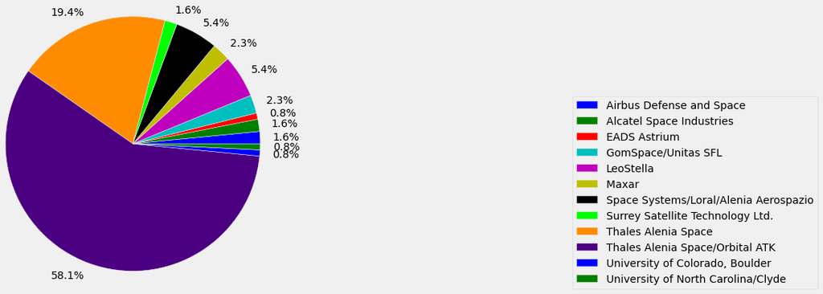

```python
#USA: Imports by Contractor
pie_chart(us_imp_cont_table, 7,1)
```

```python
#USA exports by sector
us_exp_users_table
```

| Country of Contractor | Civil | Commercial | Commercial/Government | Government | Government/Civil | Government/Military | Military | Military/Commercial | Military/Government |
| --- | --- | --- | --- | --- | --- | --- | --- | --- | --- |
| USA | 1 | 409 | 1 | 8 | 9 | 2 | 1 | 2 | 1 |

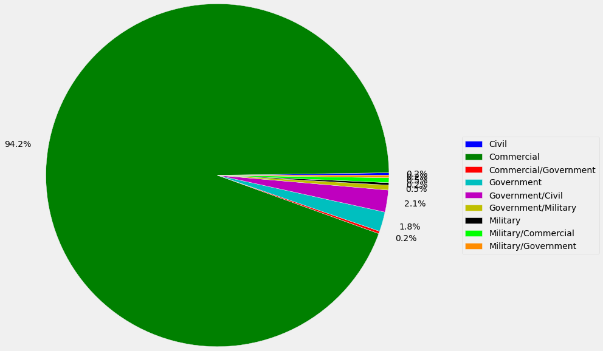

```python
#USA: Exports By Sector
pie_chart(us_exp_users_table, 5,1)
```

```python
#USA exports by contractor
us_exp_cont_table
```

| Country of Contractor | Boeing | Boeing Corp. | Boeing Defense and Space | Boeing Satellite Systems | Hughes Space and Communications Co. | Hughes Space and Communications Co. | Lockheed Martin | Lockheed Martin Commercial Space Systems | Lockheed Martin Missiles & Space | Maxar | Maxar Technologies | NASA/Goddard Space Flight Center | Northrup Grumman Innovation Systems | OneWeb Satellites/Airbus | Orbital ATK | Orbital Sciences Corp. | Orbital Space | Pumpkin Space Systems | Space Systems/Loral | SpaceQuest | Spectrum Astro (General Dynamics) | Swales Aerospace |
| --- | --- | --- | --- | --- | --- | --- | --- | --- | --- | --- | --- | --- | --- | --- | --- | --- | --- | --- | --- | --- | --- | --- |
| USA | 1 | 4 | 1 | 19 | 6 | 1 | 3 | 19 | 1 | 1 | 2 | 2 | 1 | 284 | 4 | 24 | 1 | 2 | 44 | 10 | 1 | 3 |

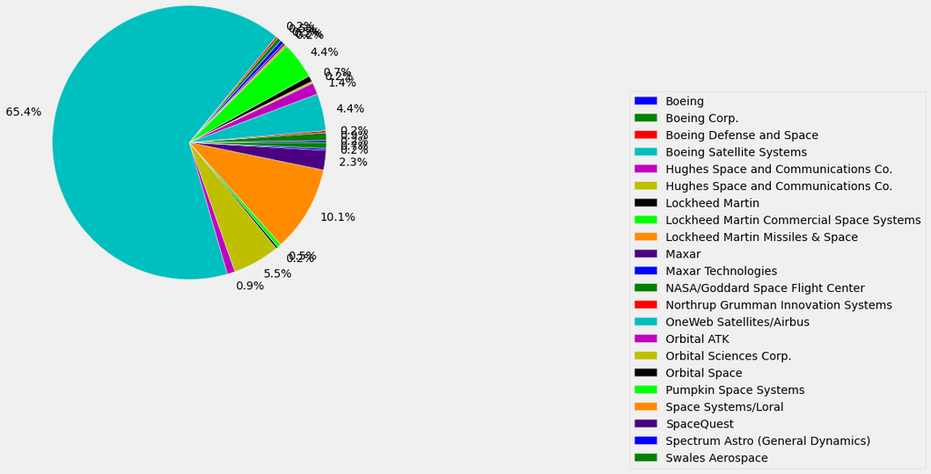

```python
#USA: Exports By Contractor
pie_chart(us_exp_cont_table, 7,1)
```

# CHINA

```python
#China: import/export analysis

cn_imp_users_table = imp_users_table_getter("China")
cn_exp_users_table = exp_users_table_getter("China")
cn_imp_cont_table = imp_cont_table_getter("China")
cn_exp_cont_table = exp_cont_table_getter("China")

#China imports by sector
cn_imp_users_table
```

| Country of Contractor | Commercial | Government | Government/Commercial |
| --- | --- | --- | --- |
| China | 0 | 2 | 0 |
| China/Austria | 0 | 1 | 0 |
| China/United Kingdom | 1 | 0 | 0 |
| France | 0 | 2 | 0 |
| France/Italy | 1 | 0 | 1 |
| USA | 6 | 0 | 0 |
| nan | 0 | 1 | 0 |

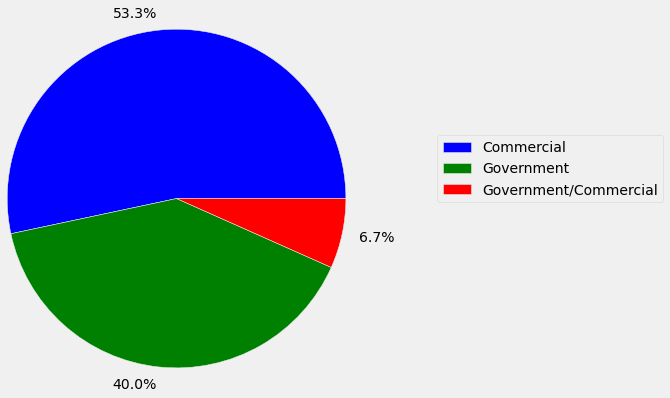

```python
#China: Imports By Sector
pie_chart(cn_imp_users_table, 4,1)
```

```python
#China imports by contractor
cn_imp_cont_table
```

| Country of Contractor | Boeing Satellite Systems | China Academy of Space Technology (CAST) | Chinese Academy of Sciences | Chinese Academy of Sciences/Austrian Academy of Sciences | Space Systems/Loral | Thales Alenia Space | Tsinghua University/University of Surrey | nan |
| --- | --- | --- | --- | --- | --- | --- | --- | --- |
| China | 0 | 1 | 1 | 0 | 0 | 0 | 0 | 0 |
| China/Austria | 0 | 0 | 0 | 1 | 0 | 0 | 0 | 0 |
| China/United Kingdom | 0 | 0 | 0 | 0 | 0 | 0 | 1 | 0 |
| France | 0 | 0 | 0 | 0 | 0 | 2 | 0 | 0 |
| France/Italy | 0 | 0 | 0 | 0 | 0 | 2 | 0 | 0 |
| USA | 1 | 0 | 0 | 0 | 5 | 0 | 0 | 0 |
| nan | 0 | 0 | 0 | 0 | 0 | 0 | 0 | 1 |

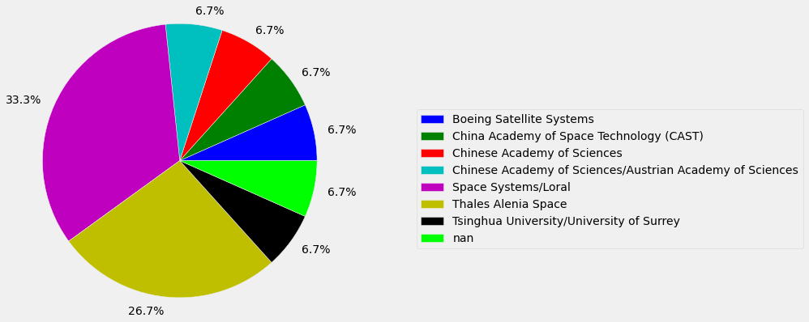

```python
#China: Imports By Contractor
pie_chart(cn_imp_cont_table, 6,1)
```

```python
#China exports by sector
cn_exp_users_table
```

| Country of Contractor | Commercial | Government | Government/Commercial |
| --- | --- | --- | --- |
| China | 7 | 11 | 1 |

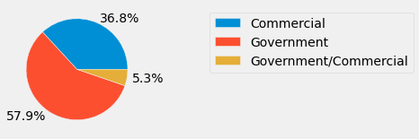

```python
#China: Exports By Sector
pie_chart(cn_exp_users_table, 3.2,1)
```

```python
#China exports by contractor
cn_exp_cont_table
```

| Country of Contractor | CAST/DFH Satellite Co. Ltd. | China Academy of Space Technology (CAST) | China Aerospace Science and Technology Corp. (CASC) | Chinese Academy of Space Technology (CASC) | Innovation Academy for Microsatellites, Chinese Academy of Sciences | Shanghai Institute of Microsatellite Innovation, Chinese Academy of Sciences | Shenzhen Aerospace Oriental Red Sea Satellite Co. | Spacety Aerospace Co. |
| --- | --- | --- | --- | --- | --- | --- | --- | --- |
| China | 2 | 9 | 1 | 1 | 2 | 2 | 1 | 1 |

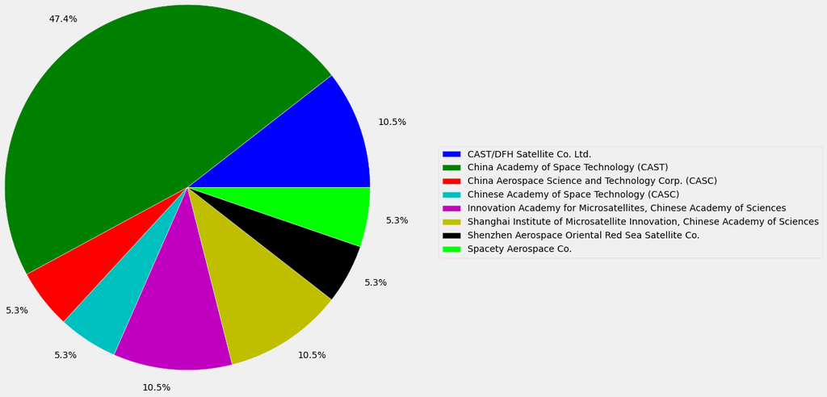

```python
#China: Exports By Contractor
pie_chart(cn_exp_cont_table, 7.5,1)
```

# RUSSIA

```python
#Russia: import/export analysis

ru_imp_users_table = imp_users_table_getter("Russia")
ru_exp_users_table = exp_users_table_getter("Russia")
ru_imp_cont_table = imp_cont_table_getter("Russia")
ru_exp_cont_table = exp_cont_table_getter("Russia")

#Russia imports by sector
ru_imp_users_table
```

| Country of Contractor | Civil | Commercial | Government | Military |
| --- | --- | --- | --- | --- |
| France | 0 | 2 | 0 | 0 |
| France/United Kingdom/Germany/Spain | 0 | 2 | 0 | 0 |
| Germany | 1 | 0 | 0 | 0 |
| Russia/France | 0 | 3 | 1 | 0 |
| Ukraine | 0 | 0 | 0 | 1 |

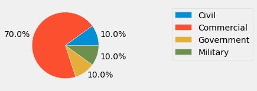

```python
#Russia: Imports By Sector
pie_chart(ru_imp_users_table, 2.8,1)
```

```python
#Russia imports by contractor
ru_imp_cont_table
```

| Country of Contractor | Airbus Defense and Space | German Orbital Systems | ISS Reshetnev/Thales Alenia Space | KB Yuznoye | NPO-PM/Alcatel | NPO-PM/Thales Alenia Space | Thales | Thales Alenia Space |
| --- | --- | --- | --- | --- | --- | --- | --- | --- |
| France | 0 | 0 | 0 | 0 | 0 | 0 | 1 | 1 |
| France/United Kingdom/Germany/Spain | 2 | 0 | 0 | 0 | 0 | 0 | 0 | 0 |
| Germany | 0 | 1 | 0 | 0 | 0 | 0 | 0 | 0 |
| Russia/France | 0 | 0 | 1 | 0 | 1 | 2 | 0 | 0 |
| Ukraine | 0 | 0 | 0 | 1 | 0 | 0 | 0 | 0 |

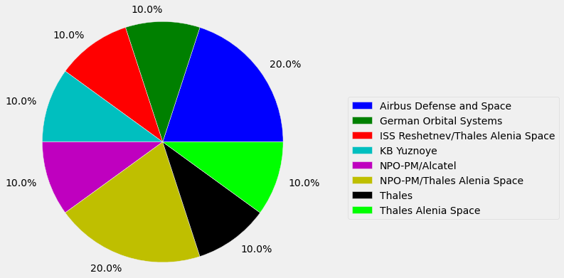

```python
#Russia: Imports By Contractor
pie_chart(ru_imp_cont_table, 4.5,1)
```

```python
#Russia exports by sector
ru_exp_users_table
```

| Country of Contractor | Commercial | Government | Military |
| --- | --- | --- | --- |
| Russia | 1 | 3 | 1 |

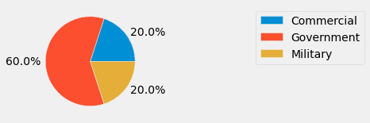

```python
#Russia: Exports By Sector
pie_chart(ru_exp_users_table, 3,1)
```

```python
#Russia exports by contractor
ru_exp_cont_table
```

| Country of Contractor | Khrunichev | Lavochkin | NPO Mashinostroyeniya | NPO VNIIEM | RKK Energia |
| --- | --- | --- | --- | --- | --- |
| Russia | 1 | 1 | 1 | 1 | 1 |

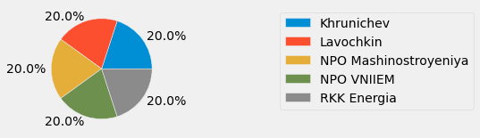

```python
#Russia: Exports By Contractor
pie_chart(ru_exp_cont_table, 3.5,1)
```

# Predictive Launch Analytics (Forecasting)

```python
year_array = make_array()
for i in Master_Table.column("Date of Launch"):
    if i == "nan":
        stat = "nan"
        year_array = np.append(year_array, stat)
    else:
        stat = int(np.array(i.split("/")).item(2))
        year_array = np.append(year_array, stat)
#For specific sector: .where("Users", are.containing(sector))
Master_Table_Dates = Master_Table.drop("Date of Launch").with_columns("Date of Launch", year_array)
Master_Table_Dates.show(10)
```

| Name of Satellite, Alternate Names | Current Official Name of Satellite | Country/Org of UN Registry | Country of Operator/Owner | Operator/Owner | Users | Purpose | Detailed Purpose | Class of Orbit | Type of Orbit | Longitude of GEO (degrees) | Perigee (km) | Apogee (km) | Eccentricity | Inclination (degrees) | Period (minutes) | Launch Mass (kg.) | Dry Mass (kg.) | Power (watts) | Expected Lifetime (yrs.) | Contractor | Launch Site | Launch Vehicle | COSPAR Number | NORAD Number | Comments | Unnamed: 28 | Source Used for Orbital Data | Source | Source.1 | … |
| --- | --- | --- | --- | --- | --- | --- | --- | --- | --- | --- | --- | --- | --- | --- | --- | --- | --- | --- | --- | --- | --- | --- | --- | --- | --- | --- | --- | --- | --- | --- |
| 1HOPSAT-TD (1st-generation High Optical Performance Sate ... | 1HOPSAT-TD | NR | USA | Hera Systems | Commercial | Earth Observation | Infrared Imaging | LEO | Non-Polar Inclined | 0 | 566 | 576 | 0.000720357 | 36.9 | 96.08 | 22 | nan | nan | 0.5 | Hera Systems | Satish Dhawan Space Centre | PSLV | 2019-089H | 44859 | Pathfinder for planned earth observation constellation. | nan | JMSatcat/3_20 | https://spaceflightnow.com/2019/12/11/indias-50th-pslv-l ... | https://www.herasys.com/ | … |
| Aalto-1 | Aalto-1 | Finland | Finland | Aalto University | Civil | Technology Development | nan | LEO | Sun-Synchronous | 0 | 497 | 517 | 0.00145 | 97.45 | 94.7 | 5 | nan | 4.5 | 2 | Aalto University | Satish Dhawan Space Centre | PSLV | 2017-036L | 42775 | Technology development and education. | nan | JMSatcat/10_17 | https://directory.eoportal.org/web/eoportal/satellite-mi ... | nan | … |
| AAUSat-4 | AAUSat-4 | Denmark | Denmark | University of Aalborg | Civil | Earth Observation | Automatic Identification System (AIS) | LEO | Sun-Synchronous | 0 | 442 | 687 | 0.0177 | 98.2 | 95.9 | 1 | nan | nan | nan | University of Aalborg | Guiana Space Center | Soyuz-2.1a | 2016-025E | 41460 | Carries AIS system. | nan | Space50 | http://spaceflightnow.com/2016/04/26/soyuz-blasts-off-wi ... | nan | … |
| ABS-2 (Koreasat-8, ST-3) | ABS-2 | NR | Multinational | Asia Broadcast Satellite Ltd. | Commercial | Communications | nan | GEO | nan | 75 | 35,778 | 35,793 | 0.000178 | 0.08 | 1436.03 | 6,330 | nan | 16,000 | 15 | Space Systems/Loral | Guiana Space Center | Ariane 5 ECA | 2014-006A | 39508 | 32 C-band, 51 Ku-band, and 6 Ka-band transponders. $214 ... | nan | ZARYA | http://www.absatellite.net/satellite-fleet/?sat=abs6 | nan | … |
| ABS-2A | ABS-2A | NR | Multinational | Asia Broadcast Satellite Ltd. | Commercial | Communications | nan | GEO | nan | -75 | 35,700 | 35,700 | 0 | 0 | 1436.1 | 1,800 | nan | nan | 15 | Boeing Satellite Systems | Cape Canaveral | Falcon 9 | 2016-038A | 41588 | nan | nan | Estimated | nan | nan | … |
| ABS-3A | ABS-3A | NR | Multinational | Asia Broadcast Satellite Ltd. | Commercial | Communications | nan | GEO | nan | -3 | 35,788 | 35,803 | 0.000178 | 0.1 | 1436 | 2,000 | nan | nan | 15 | Boeing Satellite Systems | Cape Canaveral | Falcon 9 | 2015-010A | 40424 | Coverage of Americas Europe and Africa. | nan | nan | http://www.absatellite.net/satellite-fleet/?sat=abs3a | nan | … |
| ABS-4 (ABS-2i, MBSat, Mobile Broadcasting Satellite, Han ... | ABS-4 | NR | Multinational | Asia Broadcast Satellite Ltd. | Commercial | Communications | nan | GEO | nan | 75 | 35,780 | 35,793 | 0.000154 | 0.01 | 1436.1 | 4,143 | 1,700 | 7,400 | 12 | Space Systems/Loral | Cape Canaveral | Atlas 3 | 2004-007A | 28184 | Purchased by ABS in 2013. | nan | JM/12_08 | http://www.absatellite.net/satellite-fleet/?sat=abs2 | nan | … |
| ABS-6 (ABS-1, LMI-1, Lockheed Martin-Intersputnik-1) | ABS-6 | NR | Multinational | Asia Broadcast Satellite Ltd. | Commercial | Communications | nan | GEO | nan | 159 | 35,777 | 35,794 | 0.000202 | 0.01 | 1436.08 | 2,894 | 1,730 | 6,800 (EOL) | 15 | Lockheed Martin | Baikonur Cosmodrome | Proton | 1999-053A | 25924 | 28 C-band, 16 Ku-band; business services, public voice a ... | nan | JM/12_08 | http://www.washingtonpost.com/wp-dyn/articles/A18888-200 ... | nan | … |
| Adelis-Sampson 1 | Adelis-Sampson 1 | NR | Israel | Asher Space Research Institute at Technion/Israeli Aircr ... | Government | Technology Development | nan | LEO | Sun-Synchronous | 0 | 538 | 561 | 0.00166 | 97.5 | 95.5 | 9 | nan | nan | nan | Asher Space Research Institute at Technion/Israeli Aircr ... | Baikonur Cosmodrome | Soyuz-2.1a | 2021-022F | 47937 | Demonstrate long-term autonomous cluster flight of multi ... | nan | JMSatcat/5_21 | https://asri.technion.ac.il/node/219 | https://spacenews.com/soyuz-2-rideshare-launch-delayed-f ... | … |
| Adelis-Sampson 2 | Adelis-Sampson 2 | NR | Israel | Asher Space Research Institute at Technion/Israeli Aircr ... | Government | Technology Development | nan | LEO | Sun-Synchronous | 0 | 539 | 599 | 0.00432 | 97.5 | 95.5 | 9 | nan | nan | nan | Asher Space Research Institute at Technion/Israeli Aircr ... | Baikonur Cosmodrome | Soyuz-2.1a | 2021-022H | 47939 | Demonstrate long-term autonomous cluster flight of multi ... | nan | JMSatcat/5_21 | https://asri.technion.ac.il/node/219 | https://spacenews.com/soyuz-2-rideshare-launch-delayed-f ... | … |

... (4844 rows omitted)

```python
New_Table = Master_Table_Dates.where("Users", are.contained_in(make_array("Military", "Government", "Military/Government", "Government/Military")))
New_Table.show(10)
```

| Name of Satellite, Alternate Names | Current Official Name of Satellite | Country/Org of UN Registry | Country of Operator/Owner | Operator/Owner | Users | Purpose | Detailed Purpose | Class of Orbit | Type of Orbit | Longitude of GEO (degrees) | Perigee (km) | Apogee (km) | Eccentricity | Inclination (degrees) | Period (minutes) | Launch Mass (kg.) | Dry Mass (kg.) | Power (watts) | Expected Lifetime (yrs.) | Contractor | Launch Site | Launch Vehicle | COSPAR Number | NORAD Number | Comments | Unnamed: 28 | Source Used for Orbital Data | Source | Source.1 | … |
| --- | --- | --- | --- | --- | --- | --- | --- | --- | --- | --- | --- | --- | --- | --- | --- | --- | --- | --- | --- | --- | --- | --- | --- | --- | --- | --- | --- | --- | --- | --- |
| Adelis-Sampson 1 | Adelis-Sampson 1 | NR | Israel | Asher Space Research Institute at Technion/Israeli Aircr ... | Government | Technology Development | nan | LEO | Sun-Synchronous | 0 | 538 | 561 | 0.00166 | 97.5 | 95.5 | 9 | nan | nan | nan | Asher Space Research Institute at Technion/Israeli Aircr ... | Baikonur Cosmodrome | Soyuz-2.1a | 2021-022F | 47937 | Demonstrate long-term autonomous cluster flight of multi ... | nan | JMSatcat/5_21 | https://asri.technion.ac.il/node/219 | https://spacenews.com/soyuz-2-rideshare-launch-delayed-f ... | … |
| Adelis-Sampson 2 | Adelis-Sampson 2 | NR | Israel | Asher Space Research Institute at Technion/Israeli Aircr ... | Government | Technology Development | nan | LEO | Sun-Synchronous | 0 | 539 | 599 | 0.00432 | 97.5 | 95.5 | 9 | nan | nan | nan | Asher Space Research Institute at Technion/Israeli Aircr ... | Baikonur Cosmodrome | Soyuz-2.1a | 2021-022H | 47939 | Demonstrate long-term autonomous cluster flight of multi ... | nan | JMSatcat/5_21 | https://asri.technion.ac.il/node/219 | https://spacenews.com/soyuz-2-rideshare-launch-delayed-f ... | … |
| Adelis-Sampson 3 | Adelis-Sampson 3 | NR | Israel | Asher Space Research Institute at Technion/Israeli Aircr ... | Government | Technology Development | nan | LEO | Sun-Synchronous | 0 | 537 | 561 | 0.00173 | 97.5 | 95.5 | 9 | nan | nan | nan | Asher Space Research Institute at Technion/Israeli Aircr ... | Baikonur Cosmodrome | Soyuz-2.1a | 2021-022M | 47943 | Demonstrate long-term autonomous cluster flight of multi ... | nan | JMSatcat/5_21 | https://asri.technion.ac.il/node/219 | https://spacenews.com/soyuz-2-rideshare-launch-delayed-f ... | … |
| Advanced Orion 10 (Mentor, NRO L-44, USA 311) | USA 311 | USA | USA | National Reconnaissance Office (NRO) | Military | Earth Observation | Electronic Intelligence | GEO | nan | 0 | 35,700 | 35,800 | 0.00119 | 0 | 1437.6 | 5,400 | nan | nan | nan | National Reconnaissance Laboratory (?) | Cape Canaveral | Delta 4 Heavy | 2020-095A | 47237 | ELINT. | nan | Estimated | https://spaceflightnow.com/2020/12/11/delta-4-heavy-laun ... | nan | … |
| Advanced Orion 4 (Mentor, NROL 6, USA 139) | USA 139 | USA | USA | National Reconnaissance Office (NRO) | Military | Earth Observation | Electronic Intelligence | GEO | nan | -26 | 35,560 | 36,013 | 0.00537 | 7.72 | 1436.14 | 5,200 | nan | nan | nan | TRW Space and Electronics | Cape Canaveral | Titan IVA | 1998-029A | 25336 | ELINT. | nan | JM/12_08 | http://www.sciencepresse.qc.ca/clafleur/Spacecrafts-1998 ... | nan | … |
| Advanced Orion 5 (Mentor, NROL 19, USA 171) | USA 171 | USA | USA | National Reconnaissance Office (NRO) | Military | Earth Observation | Electronic Intelligence | GEO | nan | 68 | 35,589 | 35,984 | 0.00468 | 3.2 | 1436.1 | 5,200 | nan | nan | nan | TRW Space and Electronics | Cape Canaveral | Titan IV | 2003-041A | 27937 | Electronic intelligence (ELINT). | nan | JM/12_08 | http://www.sciencepresse.qc.ca/clafleur/Spacecrafts-2003 ... | nan | … |
| Advanced Orion 6 (Mentor, NRO L-26, USA 202) | USA 202 | USA | USA | National Reconnaissance Office (NRO) | Military | Earth Observation | Electronic Intelligence | GEO | nan | 44 | 35,714 | 35,937 | 0.00264 | 2.89 | 1438.8 | 5,400 | nan | nan | nan | National Reconnaissance Laboratory (?) | Cape Canaveral | Delta 4 Heavy | 2009-001A | 33490 | ELINT. | nan | SC - ASCR | http://www.globalsecurity.org/space/systems/trumpet.htm | nan | … |
| Advanced Orion 7 (Mentor, NRO L-32, USA 223) | USA 223 | USA | USA | National Reconnaissance Office (NRO) | Military | Earth Observation | Electronic Intelligence | GEO | nan | 95 | 35,500 | 35,500 | 0 | 0 | 1436 | 5,000 | nan | nan | nan | National Reconnaissance Laboratory (?) | Cape Canaveral | Delta 4 Heavy | 2010-063A | 37232 | ELINT. | nan | SC - ASCR | http://forum.nasaspaceflight.com/index.php?topic=11127.45 | nan | … |
| Advanced Orion 8 (Mentor, NRO L-15, USA 237) | USA 237 | USA | USA | National Reconnaissance Office (NRO) | Military | Earth Observation | Electronic Intelligence | GEO | nan | 60 | 35,771 | 35,805 | 0.000403 | 0 | 1436.1 | 5,000 | nan | nan | nan | National Reconnaissance Laboratory (?) | Cape Canaveral | Delta 4 Heavy | 2012-034A | 38528 | ELINT. | nan | CalSky | http://www.nasaspaceflight.com/2012/06/delta-iv-heavy-la ... | nan | … |
| Advanced Orion 9 (Mentor, NRO L-37, USA 268) | USA 268 | USA | USA | National Reconnaissance Office (NRO) | Military | Earth Observation | Electronic Intelligence | GEO | nan | 102.6 | 35,613 | 35,903 | 0.00344 | 7.51 | 1437.19 | 5,000 | nan | nan | nan | National Reconnaissance Laboratory (?) | Cape Canaveral | Delta 4 Heavy | 2016-036A | 41584 | ELINT. | nan | ZARYA | http://spaceflightnow.com/2016/06/11/triple-barrel-delta ... | nan | … |

... (965 rows omitted)

```python
Launch_by_Date = New_Table.pivot("Country of Operator/Owner", "Date of Launch")
Launch_by_Date.show()
```

| Date of Launch | Algeria | Argentina | Azerbaijan | Bangladesh | Belarus | Bolivia | Brazil | Canada | Chile | China | China/Brazil | China/France | China/Italy | Colombia | Czech Republic | Denmark | ESA | ESA/USA | ESA/USA/Russia | Egypt | Ethiopia | France | France/Israel | France/Italy | France/Italy/Belgium/Spain/Greece | France/USA | Germany | India | India/Canada | … |
| --- | --- | --- | --- | --- | --- | --- | --- | --- | --- | --- | --- | --- | --- | --- | --- | --- | --- | --- | --- | --- | --- | --- | --- | --- | --- | --- | --- | --- | --- | --- |
| 1988.0 | 0 | 0 | 0 | 0 | 0 | 0 | 0 | 0 | 0 | 0 | 0 | 0 | 0 | 0 | 0 | 0 | 0 | 0 | 0 | 0 | 0 | 0 | 0 | 0 | 0 | 0 | 0 | 0 | 0 | … |
| 1989.0 | 0 | 0 | 0 | 0 | 0 | 0 | 0 | 0 | 0 | 0 | 0 | 0 | 0 | 0 | 0 | 0 | 0 | 0 | 0 | 0 | 0 | 0 | 0 | 0 | 0 | 0 | 0 | 0 | 0 | … |
| 1990.0 | 0 | 0 | 0 | 0 | 0 | 0 | 0 | 0 | 0 | 0 | 0 | 0 | 0 | 0 | 0 | 0 | 0 | 1 | 0 | 0 | 0 | 0 | 0 | 0 | 0 | 0 | 0 | 0 | 0 | … |
| 1992.0 | 0 | 0 | 0 | 0 | 0 | 0 | 0 | 0 | 0 | 0 | 0 | 0 | 0 | 0 | 0 | 0 | 0 | 0 | 0 | 0 | 0 | 0 | 0 | 0 | 0 | 0 | 0 | 0 | 0 | … |
| 1993.0 | 0 | 0 | 0 | 0 | 0 | 0 | 1 | 0 | 0 | 0 | 0 | 0 | 0 | 0 | 0 | 0 | 0 | 0 | 0 | 0 | 0 | 0 | 0 | 0 | 0 | 0 | 0 | 0 | 0 | … |
| 1994.0 | 0 | 0 | 0 | 0 | 0 | 0 | 0 | 0 | 0 | 0 | 0 | 0 | 0 | 0 | 0 | 0 | 0 | 0 | 0 | 0 | 0 | 0 | 0 | 0 | 0 | 0 | 0 | 0 | 0 | … |
| 1995.0 | 0 | 0 | 0 | 0 | 0 | 0 | 0 | 0 | 0 | 0 | 0 | 0 | 0 | 0 | 0 | 0 | 0 | 0 | 0 | 0 | 0 | 0 | 0 | 0 | 0 | 0 | 0 | 0 | 0 | … |
| 1996.0 | 0 | 0 | 0 | 0 | 0 | 0 | 0 | 0 | 0 | 0 | 0 | 0 | 0 | 0 | 0 | 0 | 0 | 0 | 0 | 0 | 0 | 0 | 0 | 0 | 0 | 0 | 0 | 0 | 0 | … |
| 1997.0 | 0 | 0 | 0 | 0 | 0 | 0 | 0 | 0 | 0 | 0 | 0 | 0 | 0 | 0 | 0 | 0 | 0 | 0 | 0 | 0 | 0 | 0 | 0 | 0 | 0 | 0 | 0 | 0 | 0 | … |
| 1998.0 | 0 | 0 | 0 | 0 | 0 | 0 | 1 | 0 | 0 | 0 | 0 | 0 | 0 | 0 | 0 | 0 | 0 | 0 | 0 | 0 | 0 | 0 | 0 | 0 | 0 | 0 | 0 | 0 | 0 | … |
| 1999.0 | 0 | 0 | 0 | 0 | 0 | 0 | 0 | 0 | 0 | 0 | 0 | 0 | 0 | 0 | 0 | 0 | 1 | 0 | 0 | 0 | 0 | 0 | 0 | 0 | 0 | 0 | 1 | 0 | 0 | … |
| 2000.0 | 0 | 0 | 0 | 0 | 0 | 0 | 0 | 0 | 0 | 0 | 0 | 0 | 0 | 0 | 0 | 0 | 4 | 0 | 0 | 0 | 0 | 0 | 0 | 0 | 0 | 0 | 0 | 0 | 0 | … |
| 2001.0 | 0 | 0 | 0 | 0 | 0 | 0 | 0 | 0 | 0 | 0 | 0 | 0 | 0 | 0 | 0 | 0 | 1 | 0 | 0 | 0 | 0 | 0 | 0 | 0 | 0 | 0 | 0 | 0 | 0 | … |
| 2002.0 | 0 | 0 | 0 | 0 | 0 | 0 | 0 | 0 | 0 | 0 | 0 | 0 | 0 | 0 | 0 | 0 | 0 | 0 | 1 | 0 | 0 | 0 | 0 | 0 | 0 | 0 | 0 | 0 | 0 | … |
| 2003.0 | 0 | 0 | 0 | 0 | 0 | 0 | 0 | 2 | 0 | 1 | 0 | 0 | 0 | 0 | 0 | 0 | 0 | 0 | 0 | 0 | 0 | 0 | 0 | 0 | 0 | 0 | 0 | 1 | 0 | … |
| 2004.0 | 0 | 0 | 0 | 0 | 0 | 0 | 0 | 0 | 0 | 4 | 0 | 0 | 0 | 0 | 0 | 0 | 0 | 0 | 0 | 0 | 0 | 0 | 0 | 0 | 1 | 0 | 0 | 0 | 0 | … |
| 2005.0 | 0 | 0 | 0 | 0 | 0 | 0 | 0 | 0 | 0 | 1 | 0 | 0 | 0 | 0 | 0 | 0 | 0 | 0 | 0 | 0 | 0 | 1 | 0 | 0 | 0 | 0 | 0 | 1 | 0 | … |
| 2006.0 | 0 | 0 | 0 | 0 | 0 | 0 | 0 | 0 | 0 | 2 | 0 | 0 | 0 | 0 | 0 | 0 | 0 | 0 | 0 | 0 | 0 | 1 | 0 | 0 | 0 | 1 | 1 | 0 | 0 | … |
| 2007.0 | 0 | 0 | 0 | 0 | 0 | 0 | 0 | 0 | 0 | 0 | 0 | 0 | 0 | 0 | 0 | 0 | 0 | 0 | 0 | 0 | 0 | 0 | 0 | 0 | 0 | 0 | 2 | 2 | 0 | … |
| 2008.0 | 0 | 0 | 0 | 0 | 0 | 0 | 0 | 0 | 0 | 9 | 0 | 0 | 0 | 0 | 0 | 0 | 0 | 0 | 0 | 0 | 0 | 0 | 0 | 0 | 0 | 0 | 2 | 1 | 0 | … |
| 2009.0 | 0 | 0 | 0 | 0 | 0 | 0 | 0 | 0 | 0 | 4 | 0 | 0 | 0 | 0 | 0 | 0 | 2 | 0 | 0 | 0 | 0 | 2 | 0 | 0 | 1 | 0 | 1 | 1 | 0 | … |
| 2010.0 | 1 | 0 | 0 | 0 | 0 | 0 | 0 | 0 | 0 | 14 | 0 | 0 | 0 | 0 | 0 | 0 | 1 | 0 | 0 | 1 | 0 | 0 | 0 | 0 | 0 | 0 | 2 | 1 | 0 | … |
| 2011.0 | 0 | 0 | 0 | 0 | 0 | 0 | 0 | 0 | 1 | 14 | 0 | 0 | 0 | 0 | 0 | 0 | 0 | 0 | 0 | 0 | 0 | 4 | 0 | 1 | 0 | 0 | 0 | 3 | 1 | … |
| 2012.0 | 0 | 0 | 0 | 0 | 1 | 0 | 0 | 0 | 0 | 21 | 0 | 0 | 0 | 0 | 0 | 0 | 0 | 0 | 0 | 0 | 0 | 0 | 0 | 0 | 0 | 0 | 0 | 2 | 0 | … |
| 2013.0 | 0 | 0 | 1 | 0 | 0 | 1 | 0 | 3 | 0 | 12 | 0 | 0 | 0 | 0 | 0 | 0 | 4 | 0 | 0 | 0 | 0 | 0 | 0 | 0 | 0 | 0 | 0 | 3 | 0 | … |
| 2014.0 | 0 | 0 | 0 | 0 | 0 | 0 | 0 | 0 | 0 | 17 | 1 | 0 | 0 | 0 | 0 | 0 | 1 | 0 | 0 | 0 | 0 | 0 | 0 | 1 | 0 | 0 | 0 | 4 | 0 | … |
| 2015.0 | 0 | 0 | 0 | 0 | 0 | 0 | 0 | 0 | 0 | 16 | 0 | 0 | 0 | 0 | 0 | 0 | 1 | 0 | 0 | 0 | 0 | 0 | 0 | 1 | 0 | 0 | 0 | 3 | 0 | … |
| 2016.0 | 3 | 0 | 0 | 0 | 1 | 0 | 0 | 1 | 0 | 17 | 0 | 0 | 0 | 0 | 0 | 0 | 2 | 0 | 0 | 0 | 0 | 0 | 0 | 0 | 0 | 0 | 1 | 9 | 0 | … |
| 2017.0 | 1 | 0 | 0 | 0 | 0 | 0 | 0 | 0 | 0 | 19 | 0 | 0 | 0 | 0 | 1 | 0 | 2 | 0 | 0 | 0 | 0 | 0 | 1 | 0 | 0 | 0 | 0 | 7 | 0 | … |
| 2018.0 | 0 | 1 | 1 | 1 | 0 | 0 | 0 | 0 | 0 | 51 | 0 | 1 | 1 | 1 | 0 | 2 | 2 | 0 | 0 | 0 | 0 | 1 | 0 | 0 | 0 | 0 | 1 | 7 | 0 | … |
| 2019.0 | 0 | 0 | 0 | 0 | 0 | 0 | 0 | 3 | 0 | 26 | 1 | 0 | 0 | 0 | 0 | 0 | 3 | 0 | 0 | 2 | 1 | 0 | 0 | 0 | 0 | 0 | 0 | 5 | 0 | … |
| 2020.0 | 0 | 1 | 0 | 0 | 0 | 0 | 0 | 0 | 0 | 38 | 0 | 0 | 0 | 0 | 0 | 0 | 6 | 0 | 0 | 0 | 1 | 1 | 0 | 0 | 0 | 0 | 0 | 3 | 0 | … |
| 2021.0 | 0 | 0 | 0 | 0 | 0 | 0 | 1 | 0 | 0 | 53 | 0 | 0 | 0 | 0 | 0 | 0 | 2 | 0 | 0 | 0 | 0 | 4 | 0 | 0 | 0 | 0 | 1 | 0 | 0 | … |

# Some EDA data visualization code

```python
#The x-axis measures years after 1988

def launch_plot(country):
    x_column = np.arange(1, Launch_by_Date.num_rows + 1)
    y_column = Launch_by_Date.column(country)
    plot_table = Table().with_columns("Years since 1988", x_column, "Launches", y_column)
    return plot_table.plot("Years since 1988", "Launches")

def launch_scatter(country):
    x_column = np.arange(1, Launch_by_Date.num_rows + 1)
    y_column = Launch_by_Date.column(country)
    plot_table = Table().with_columns("Years since 1988", x_column, "Launches", y_column)
    return plot_table.scatter("Years since 1988", "Launches")

def launch_plot_nonzero(country):
    new_data = Launch_by_Date.where(country, are.not_equal_to(0)).select(0, country)
    x_column = new_data.column(0)
    y_column = new_data.column(1)
    plot_table = Table().with_columns("Years", x_column, "Launches", y_column)
    return plot_table.plot("Years", "Launches") and plots.xticks(range(0,22,8)) and plots.xlabel("Years")

def launch_scatter_nonzero(country):
    new_data = Launch_by_Date.where(country, are.not_equal_to(0)).select(0, country)
    x_column = new_data.column(0)
    y_column = new_data.column(1)
    plot_table = Table().with_columns("Years", x_column, "Launches", y_column)
    return plot_table.scatter("Years since 1988", "Launches")
```

```python
#Last five elements in an array:

def last_five(array):
    last_five = make_array()
    for i in make_array(5,4,3,2,1):
        stat = array.item(len(array) - i)
        last_five = np.append(last_five, stat)
    return last_five
```

### last_five was previously implemented in old code (no longer is) and is being kept in final script for potential need in the future.

```python
#Using data for launches per year beginning after a Country's first recorded launch

def shortened_table(country):
    n = 0
    for i in Launch_by_Date.column(country):
        if i != 0:
            break
        else:
            n += 1
    return Launch_by_Date.select("Date of Launch", country).take(np.arange(n, Launch_by_Date.num_rows))
```

# Blueprint Model: Sampling from Segmented Means + St. Devs.

```python
#First initiate working table
working_table = shortened_table("China")

#Compute forecast point function built with the intention of appendage
def forecast_point(working_table, country):
    global_mean = np.mean(working_table.column(country))
    global_std = np.std(working_table.column(country))
    W_Q = working_table.num_rows
    H_table = working_table.where(country, are.above_or_equal_to(global_mean))
    H_mean = np.mean(H_table.column(country))
    H_Q = H_table.num_rows
    L_table = working_table.where(country, are.below(global_mean))
    L_mean = np.mean(L_table.column(country))
    L_Q = L_table.num_rows
    model_p = (L_Q/W_Q, H_Q/W_Q)
    select = sample_proportions(1, model_p)
    return round(select.item(0)*L_mean + select.item(1)*H_mean + global_std)
```

# The Real Predictor: Using Moving Averages to Predict Launch Behavior

#### "Segmentor"

```python
#Creates an array of segmented indicies into groups of 4. Appends the last index if it is not already in array
#Arg for this function must be a table in the form output of shortened_table(country)
def seg_sim_array(tbl):
    data = np.arange(0,tbl.num_rows - 1, 4)
    new_data = np.append(data, tbl.num_rows)
    arr = Table().with_columns("Data", new_data).group("Data").column("Data")
    return arr
```

#### Predicts new data

```python
#Computes the averages of segmented data (by index) and outputs an array of "k-means"
#Arg for this function must be a table in the form output of shortened_table(country)
def seg_sim(tbl):
    indexer = seg_sim_array(tbl)
    means = make_array()
    for i in np.arange(len(seg_sim_array(tbl))-1):
        stat = np.mean(tbl.take(np.arange(indexer.item(i), indexer.item(i+1))).column(1))
        means = np.append(means, stat)
    new_mean = means.item(len(means)-1) + np.round(int(np.mean(np.diff(means))))
    moving_std = np.round(int(np.std(np.diff(means))))
    sampling_arr = np.arange(new_mean - (2*moving_std), (new_mean + (2*moving_std)) + 1, 1)
    return np.random.choice(sampling_arr, 5)
```

#### Generates table with newly predicted data for desired amount of years into the future

```python
#Predicts future data by calculating a moving average (mean of np.diff(seg_sim(country))) and
#np.std(np.diff(seg_sim(country))), adding moving ave to most recent segmented ave and drawing len(segment) number of
#random selections from [new ave ± 2*std] to yield predicted data.
#new predictions along with new years are added to shortened_table(country), which is initially assigned to a variable

#This process is repeated in order to continually update moving average and std based on forecasted data

def master_sim(tbl, segs):
    country = np.array(tbl.labels)[1]
    for i in np.arange(segs):
        new_launch_data = seg_sim(tbl)
        col_0 = tbl.column(0)
        col_1 = tbl.column(1)
        for i in np.arange(1, len(new_launch_data)+1):
            stat_0 = str((float(col_0.item(len(col_0) -1))) + 1)
            col_0 = np.append(col_0, stat_0)
            stat_1 = new_launch_data.item(i-1)
            col_1 = np.append(col_1, stat_1)
        tbl = Table().with_columns("Date of Launch", col_0, country, col_1)
    return tbl


tbl = shortened_table("China")
master_sim(tbl, 3).show()
```

| Date of Launch | China |
| --- | --- |
| 2003.0 | 1 |
| 2004.0 | 4 |
| 2005.0 | 1 |
| 2006.0 | 2 |
| 2007.0 | 0 |
| 2008.0 | 9 |
| 2009.0 | 4 |
| 2010.0 | 14 |
| 2011.0 | 14 |
| 2012.0 | 21 |
| 2013.0 | 12 |
| 2014.0 | 17 |
| 2015.0 | 16 |
| 2016.0 | 17 |
| 2017.0 | 19 |
| 2018.0 | 51 |
| 2019.0 | 26 |
| 2020.0 | 38 |
| 2021.0 | 53 |
| 2022.0 | 42 |
| 2023.0 | 43 |
| 2024.0 | 51 |
| 2025.0 | 49 |
| 2026.0 | 53 |
| 2027.0 | 61 |
| 2028.0 | 54 |
| 2029.0 | 56 |
| 2030.0 | 58 |
| 2031.0 | 54 |
| 2032.0 | 66.6 |
| 2033.0 | 64.6 |
| 2034.0 | 62.6 |
| 2035.0 | 61.6 |
| 2036.0 | 69.6 |

# Error Analysis: Measuring Model Against Historical Data (Chopping "Training")

### For this predictive model, percent error is calculated by taking the sum of launches for a country over the last three years and comparing that actual sum to my model's predictive sum of launches over the last three years (in a percent error calculation).

```python
def master_percent_error(tbl):
    country = np.array(tbl.labels)[1]
    working_tbl = tbl.take(np.arange(0, tbl.num_rows - 3))
    last_ind = master_sim(working_tbl, 1).num_rows - 1
    test_data = master_sim(working_tbl, 1).take(last_ind - 4, last_ind - 3, last_ind - 2).column(country)
    data_1 = sum(test_data)
    data_2 = sum(tbl.take(tbl.num_rows - 1, tbl.num_rows - 2, tbl.num_rows - 3).column(country))
    return abs(data_1 - data_2)/data_2
```

# Simulating future data 3000 times and calculating (and plotting) percent error for China:

```
0.16150997151
0.0383002209453
```

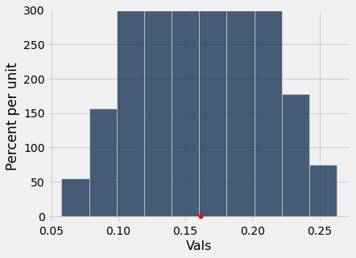

```python
hist_array = make_array()
for i in np.arange(3000):
    stat = master_percent_error(shortened_table("China"))
    hist_array = np.append(hist_array, stat)

hist_table = Table().with_columns("Vals", hist_array)
mean_ave_error = np.mean(hist_array)
hist_table.hist()
plots.scatter(mean_ave_error, 0, color='red', s=30)
plots.ylim(-0.1, 3)

print(mean_ave_error)
print(np.std(hist_array))
```

### Model is reading an average percent error of approximatley 16% and a standard deviation (in percent error) of approximately 4%

# Simulating future data 3000 times and calculating (and plotting) percent error for USA:

```
0.193980099502
0.0671542096894
```

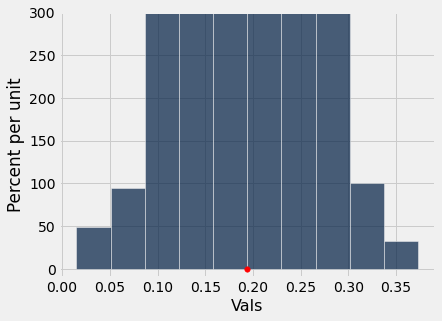

```python
hist_array = make_array()
for i in np.arange(3000):
    stat = master_percent_error(shortened_table("USA"))
    hist_array = np.append(hist_array, stat)

hist_table = Table().with_columns("Vals", hist_array)
mean_ave_error = np.mean(hist_array)
hist_table.hist()
plots.scatter(mean_ave_error, 0, color='red', s=30)
plots.ylim(-0.1, 3)

print(mean_ave_error)
print(np.std(hist_array))
```

### Model is reading an average percent error of approximatley 19% and a standard deviation (in percent error) of approximately 7%